# Math 421 - Midterm

## III. Predictive Models

Continue with the data from part I. Make sure you do not have any missing values in the data. Use the follows as the target and input variables:

*Target Variable*: Create the target variable taking value of

- `low` if the total charge of a patient (`tot`) is smaller than the median of the total charge, and
- `high` otherwise.

*Input Variables*:

- “age”,“sex”,“raceethn”,“provider”,“moa”,“mod”,“admtype”,“campus”, ‘los’
1. Use `filter` function to filter out rows where `raceethn==''` or `admtype==''`. Make sure all the categorical variables are factor, numeric variables are numeric. Set Training : Testing Split = 10 : 90

```r
library(dplyr)
library(rpart)
library(rpart.plot)
library(caret)
```

```r
df <- df %>%
  filter(raceethn != '', admtype != '') %>%
  mutate(
    raceethn = as.factor(raceethn),
    admtype = as.factor(admtype),
    sex = as.factor(sex),
    provider = as.factor(provider),
    moa = as.factor(moa),
    mod = as.factor(mod),
    campus = as.factor(campus),
    age = as.numeric(age),
    los = as.numeric(los),
    tot = as.numeric(tot)
  )
```

```r
median_tot <- median(df$tot, na.rm = TRUE)
df <- df %>%
  mutate(target = ifelse(tot < median_tot, "low", "high")) %>%
  mutate(target = as.factor(target))
```

```r
set.seed(42)
train_index <- createDataPartition(df$target, p = 0.1, list = FALSE)
train_data <- df[train_index, ]
test_data <- df[-train_index, ]
```

2. Train a decision tree using `rpart`. Plot the decision tree. Plot the variable importance ranked by the tree.

```r
tree_model <- rpart(target ~ age + sex + raceethn + provider + moa + mod + admtype + campus + los,
                    data = train_data, method = "class")
```

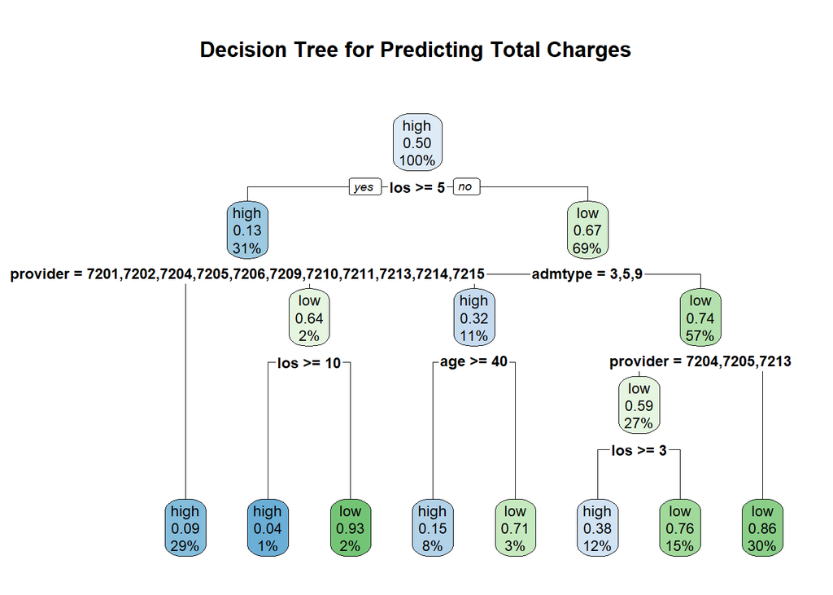

```r
rpart.plot(tree_model, main = "Decision Tree for Predicting Total Charges")
```

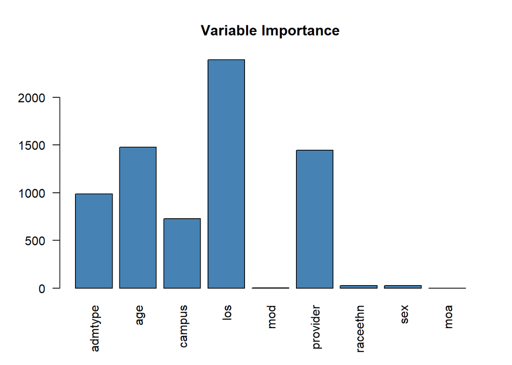

```r
importance <- as.data.frame(varImp(tree_model, scale = FALSE))
barplot(importance$Overall, names.arg = rownames(importance), main = "Variable Importance", las = 2, col = "steelblue")
```

3. Using caret for this question. Set `Training Control` to be: Use Cross-Validation of 5 folds across all models. Train & tune at least 2 different models (i.e. two different values for `method=` in the train function of caret). Plot the hyper-parameter tuning plots for each model.

```r
train_control <- trainControl(method = "cv", number = 5)
```

```r
set.seed(42)
model_tree <- train(target ~ age + sex + raceethn + provider + moa + mod + admtype + campus + los,
                    data = train_data,
                    method = "rpart",
                    trControl = train_control)
```

```r
library(randomForest)
set.seed(42)
model_rf <- train(target ~ age + sex + raceethn + provider + moa + mod + admtype + campus + los,
                  data = train_data,
                  method = "rf",
                  trControl = train_control)
```

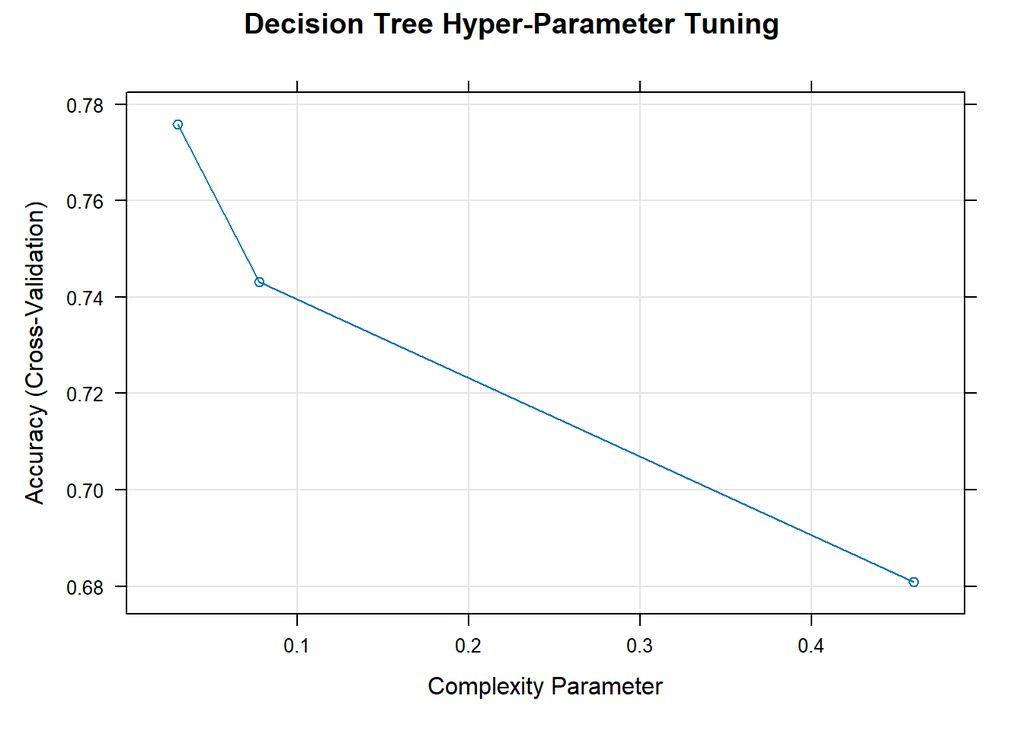

```r
plot(model_tree, main = "Decision Tree Hyper-Parameter Tuning")
```

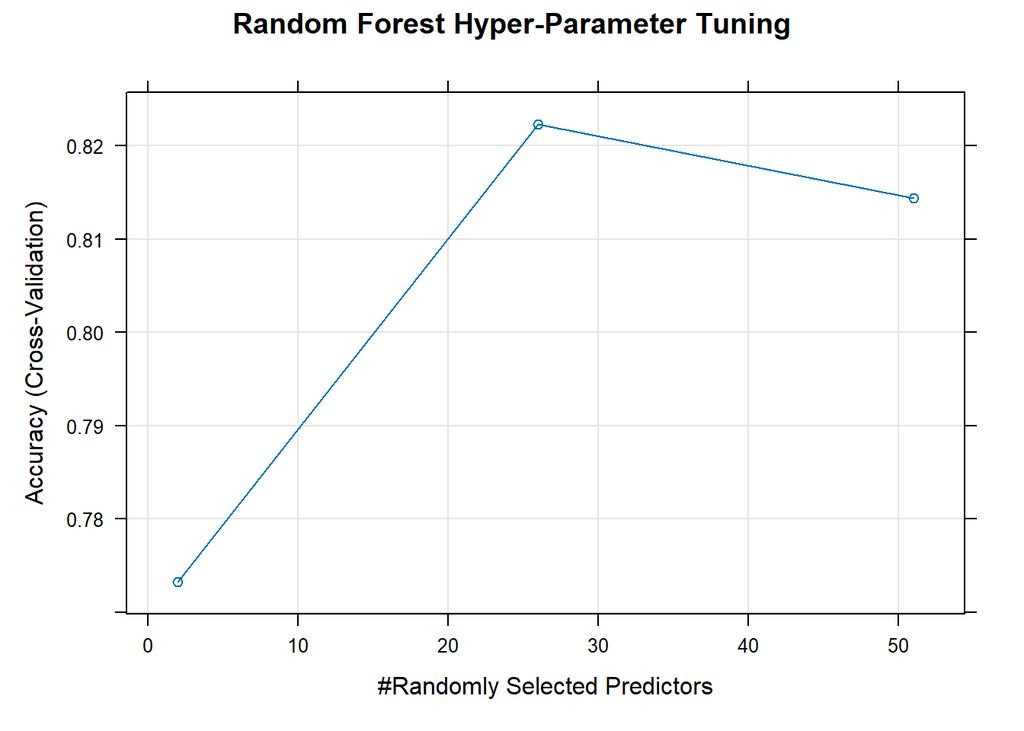

```r
plot(model_rf, main = "Random Forest Hyper-Parameter Tuning")
```

4. Plot the comparison of the models in 3.

```r
results <- resamples(list(DecisionTree = model_tree, RandomForest = model_rf))
summary(results)
```

```
##
## Call:
## summary.resamples(object = results)
##
## Models: DecisionTree, RandomForest
## Number of resamples: 5
##
## Accuracy
##                   Min.   1st Qu.    Median      Mean   3rd Qu.      Max. NA's
## DecisionTree 0.7565661 0.7647981 0.7803922 0.7758354 0.7847903 0.7926303    0
## RandomForest 0.8110545 0.8157585 0.8232066 0.8223309 0.8305882 0.8310466    0
##
## Kappa
##                   Min.   1st Qu.    Median      Mean   3rd Qu.      Max. NA's
## DecisionTree 0.5131642 0.5295722 0.5607843 0.5516733 0.5696177 0.5852284    0
## RandomForest 0.6221098 0.6315147 0.6464126 0.6446626 0.6611765 0.6620994    0
```

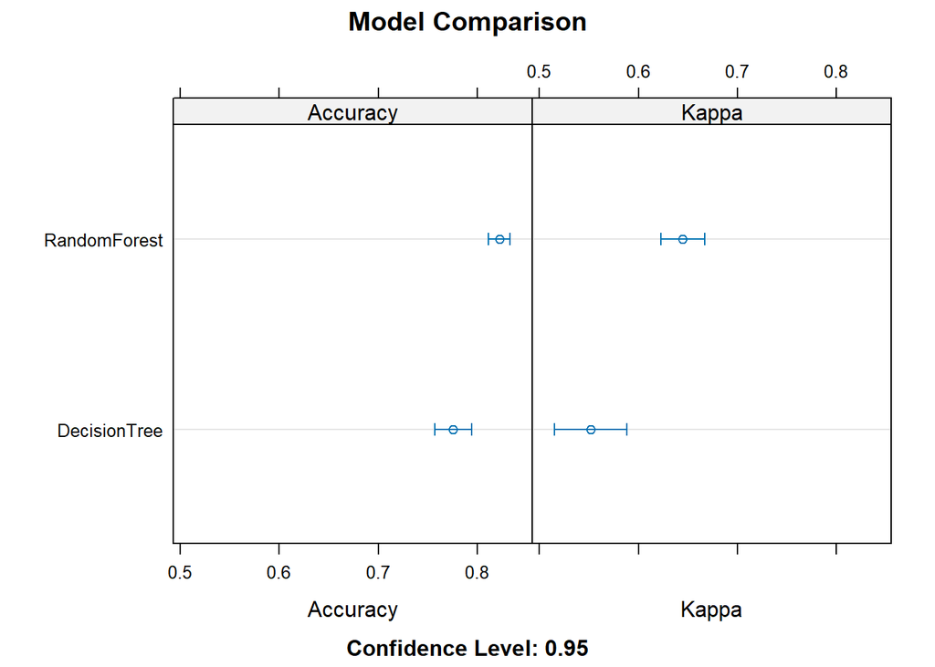

```r
dotplot(results, main = "Model Comparison")
```

5. What is your final selection for the model? Test the accuracy of your final model on the test data.

```r
final_model <- model_rf
```

```r
predictions <- predict(final_model, test_data)
conf_matrix <- confusionMatrix(predictions, test_data$target)
print(conf_matrix)
```

```
## Confusion Matrix and Statistics
##
##           Reference
## Prediction  high   low
##       high 46401  9560
##       low  10987 47825
##
##                Accuracy : 0.821
##                  95% CI : (0.8187, 0.8232)
##     No Information Rate : 0.5
##     P-Value [Acc > NIR] : < 2.2e-16
##
##                   Kappa : 0.642
##
##  Mcnemar's Test P-Value : < 2.2e-16
##
##             Sensitivity : 0.8085
##             Specificity : 0.8334
##          Pos Pred Value : 0.8292
##          Neg Pred Value : 0.8132
##              Prevalence : 0.5000
##          Detection Rate : 0.4043
##    Detection Prevalence : 0.4876
##       Balanced Accuracy : 0.8210
##
##        'Positive' Class : high
##
```

```r
median_los <- median(df$los, na.rm = TRUE)
df <- df %>%
  mutate(new_target = ifelse(los < median_los, "short", "long")) %>%
  mutate(new_target = as.factor(new_target))
```

```r
median_tot <- median(df$tot, na.rm = TRUE)
df <- df %>%
  mutate(new_target = ifelse(tot < median_tot, "low", "high")) %>%
  mutate(new_target = as.factor(target))

set.seed(42)  # For reproducibility
train_index <- createDataPartition(df$target, p = 0.1, list = FALSE)
train_data <- df[train_index, ]
test_data <- df[-train_index, ]
```

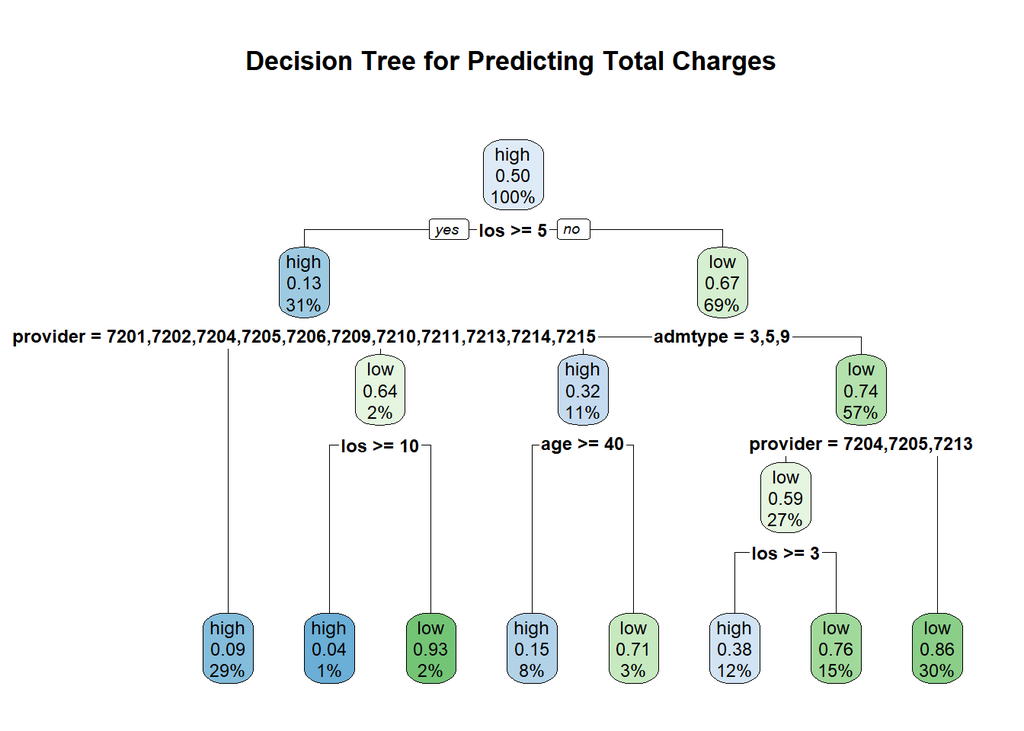

```r
tree_model <- rpart(new_target ~ age + sex + raceethn + provider + moa + mod + admtype + campus + los,
                    data = train_data, method = "class")

rpart.plot(tree_model, main = "Decision Tree for Predicting Total Charges")
```

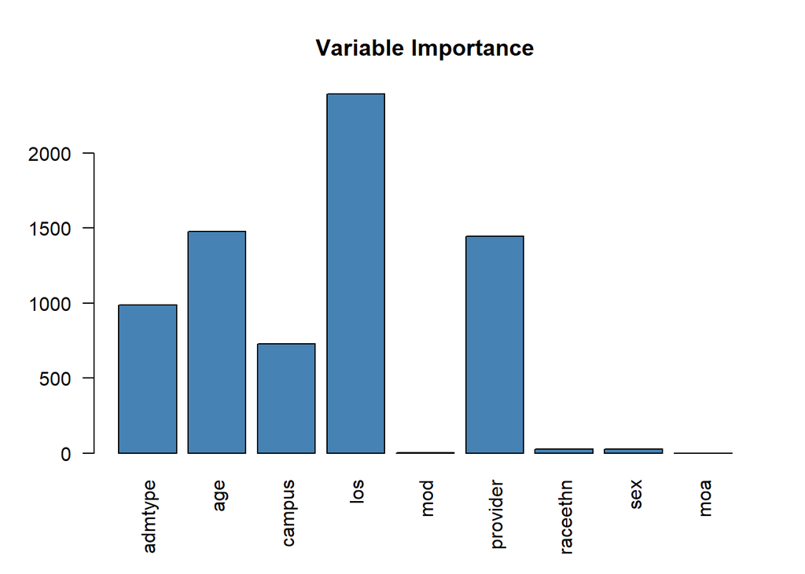

```r
importance <- as.data.frame(varImp(tree_model, scale = FALSE))
barplot(importance$Overall, names.arg = rownames(importance), main = "Variable Importance", las = 2, col = "steelblue")
```

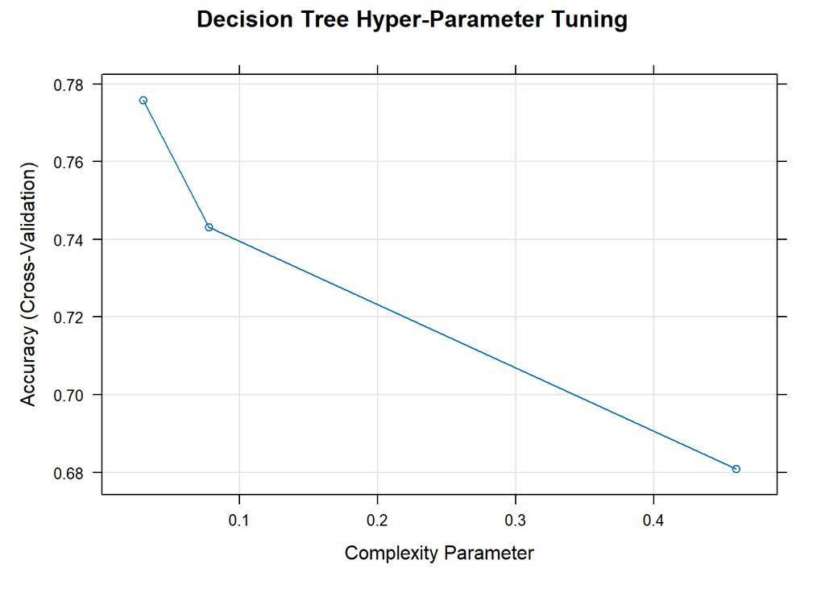

```r
train_control <- trainControl(method = "cv", number = 5)

set.seed(42)
model_tree <- train(new_target ~ age + sex + raceethn + provider + moa + mod + admtype + campus + los,
                    data = train_data,
                    method = "rpart",
                    trControl = train_control)

set.seed(42)
model_rf <- train(new_target ~ age + sex + raceethn + provider + moa + mod + admtype + campus + los,
                  data = train_data,
                  method = "rf",
                  trControl = train_control)

plot(model_tree, main = "Decision Tree Hyper-Parameter Tuning")
```